# Text Classification

# Setup

Import all necessary packages and functions.

```r
library(tidyverse)
library(tidytext)
library(stopwords)
library(here)
library(dotenv)
library(ellmer)
library(furrr)
library(future)
library(DT)
source(here("Scripts/00_functions.R"))
load_dot_env(here(".env"))
```

# Import Data

```r
subjects <-
  read_rds(here("Data/02_subjects.rds")) |>
  select(IdSubject, BusinessShortNumber, Title)
```

# Dictionary-Based Classification

Here the dictionary-based classification results will be imported. The classification is based on the presence of keywords from the curated German and French dictionaries in the paragraphs. A paragraph is classified as climate-relevant if it contains at least one keyword from the dictionary.

```r
paragraphs_classified_dict <- read_rds(here("Data/05_paragraphs_classified_dict.rds")) |>
  mutate(IdSubject = as.character(IdSubject))
```

# BERT Classification

Here the BERT-based classification results will be imported.

```r
classified_paragraphs_bert <- read_csv(here("Model-Outputs/classified_paragraphs.csv"))
classified_paragraphs_bert_cleaned <- classified_paragraphs_bert |>
  mutate(predicted_label = ifelse(predicted_label == 1, TRUE, FALSE)) |>
  select(-token_length) |>
  rename(paragraph_id = id)
```

# Compare bert- and dict-based classification

Compare the dictionary-based classification with the BERT-based classification.

```r
paragraphs_classified_joint <- paragraphs_classified_dict |>
  left_join(
    classified_paragraphs_bert_cleaned |> select(paragraph_id, predicted_label),
    by = join_by(paragraph_id)
  ) |>
  drop_na(predicted_label)
  # mutate(
  #   either_prediction = dict_prediction | predicted_label,
  #   both_predictions = dict_prediction & predicted_label)
```

Visualize the comparison results.

Show the dict prediction, the bert prediction and the overlap between the two predictions.

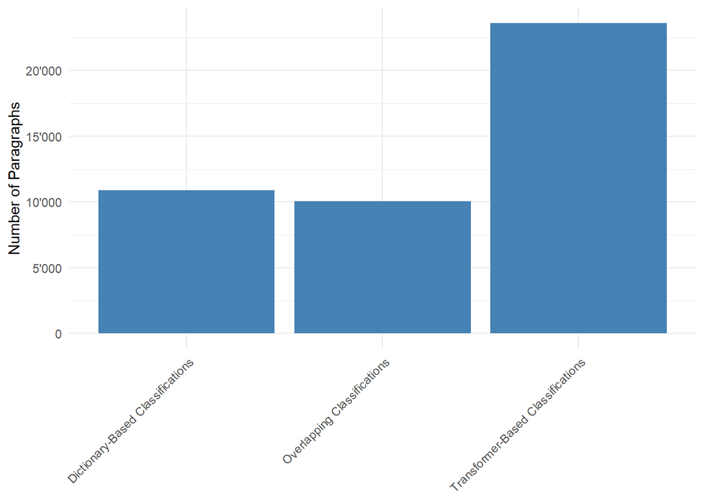

```r
df_plot <- paragraphs_classified_joint |>
  summarise(
    `Dictionary-Based Classifications` = sum(dict_prediction),
    `Transformer-Based Classifications` = sum(predicted_label),
    `Overlapping Classifications` = sum(dict_prediction & predicted_label)
  ) |>
  pivot_longer(cols = everything(), names_to = "Category", values_to = "Count")

p <- ggplot(
  df_plot, aes(
    x = Category,
    y = Count
  )
) +
  geom_col(fill = "steelblue") +
  # geom_text(aes(label = Count), vjust = 2.0, color = "black") +
  theme_minimal() +
  labs(x = NULL, y = "Number of Paragraphs") +
  scale_y_continuous(labels = scales::label_number(big.mark = "'", decimal.mark = ".", accuracy = 1)) +
  theme(
    legend.position = "none",
    axis.text.x = element_text(angle = 45, hjust = 1)
  )
ggsave(here("Outputs/05_prediction_comparison.png"), p)
write_rds(p, here("Outputs/05_prediction_comparison.rds"))
p
```

# Transcript Classification

```r
# transcript_classification <- paragraphs_classified_joint |>
#   group_by(transcript_id) |>
#   summarise(
#     n_paragraphs = n(),
#     n_climate_paragraphs = sum(predicted_label),
#     proportion_climate_paragraphs = n_climate_paragraphs / n_paragraphs,
#     climate_transcript = case_when(n_climate_paragraphs > 0 ~ TRUE,
#     .default = FALSE),
#     transcript_text = paste(paragraph_text, collapse = " "),
#     transcript_word_length = str_count(transcript_text, "\\S+"),
#     .groups = "drop"
#   ) |>
#   filter(climate_transcript == TRUE, transcript_word_length >= 50)

# write_csv(
#   transcript_classification,
#   here("Data/05_transcripts_climate.csv")
# )
```

# Pre-Processing for Business Classification

Do some preprocessing to prepare for final classification.

```r
# n_distinct(subjects$IdSubject)

# Create long table: paragraphs can have more than one bsn assigned

paragraphs_subjects_long <- left_join(
  paragraphs_classified_joint,
  subjects,
  by = join_by(IdSubject),
  relationship = "many-to-many"
) |>
  select(-IdSubject)

paragraphs_classified_wide <- paragraphs_subjects_long |>
  group_by(across(c(-BusinessShortNumber, -Title))) |>
  summarise(
    BusinessShortNumber = paste(BusinessShortNumber, collapse = " | "),
    Title = paste(Title, collapse = " | "),
    .groups = "drop"
  )
```

# Sensitivity Checks for Threshold Selection

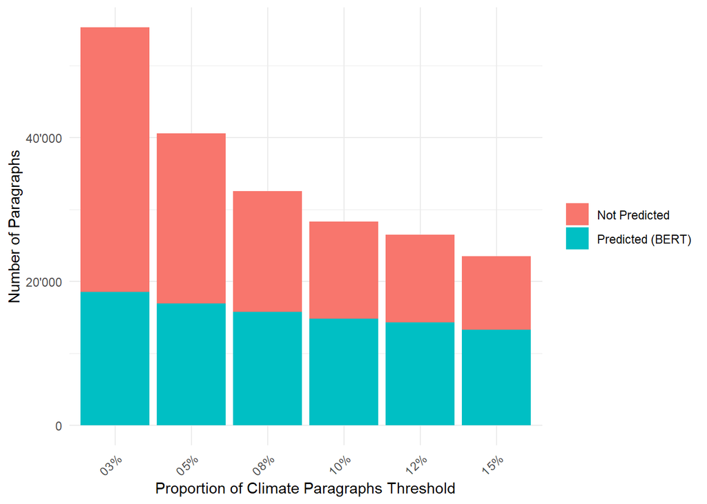

```r
# create variables with different thresholds for the proportion of climate paragraphs to be classified as climate relevant. This will be used for sensitivity checks later on.

# thresholds <- c(0.03, 0.05, 0.08, 0.1, 0.12, 0.15)

business_classification <- paragraphs_classified_wide |>
  group_by(BusinessShortNumber, Title) |>
  summarise(
    n_paragraphs = n(),
    n_climate_paragraphs = sum(dict_prediction),
    proportion_climate_paragraphs = n_climate_paragraphs / n_paragraphs,
    threshold_03 = ifelse(proportion_climate_paragraphs >= 0.03, TRUE, FALSE),
    threshold_05 = ifelse(proportion_climate_paragraphs >= 0.05, TRUE, FALSE),
    threshold_08 = ifelse(proportion_climate_paragraphs >= 0.08, TRUE, FALSE),
    threshold_10 = ifelse(proportion_climate_paragraphs >= 0.1, TRUE, FALSE),
    threshold_12 = ifelse(proportion_climate_paragraphs >= 0.12, TRUE, FALSE),
    threshold_15 = ifelse(proportion_climate_paragraphs >= 0.15, TRUE, FALSE),
    .groups = "drop"
  )

# label the paragraphs table with each threshold
# pseudo code:
# when BusinesShortNumber in threshold_03 == TRUE then threshold_03_paragraph = TRUE else FALSE

#Replace the placeholder with code that joins thresholds on the long paragraph–BSN table, pivots thresholds, and counts distinct paragraphs and distinct paragraphs with predicted_label == TRUE:

paragraphs_classified_sensitivity <- paragraphs_classified_wide |>
  left_join(
    business_classification |> select(BusinessShortNumber, starts_with("threshold")),
    by = join_by(BusinessShortNumber)
  ) |>
  pivot_longer(cols = starts_with("threshold"), names_to = "threshold", values_to = "meets_threshold") |>
  filter(meets_threshold == TRUE) |>
  group_by(threshold) |>
  summarise(
    n_paragraphs_classified = n_distinct(paragraph_id),
    n_paragraphs_predicted_label = n_distinct(paragraph_id[predicted_label == TRUE]),
    .groups = "drop"
  ) |>
  mutate(threshold = paste0(str_remove(threshold, "threshold_"), "%"))

# plot the number of paragraphs for each threshold
# Create a stacked bar by computing the "not predicted" count and pivoting to long form, then plot with fill by predicted status:

p <- paragraphs_classified_sensitivity |>
  mutate(n_paragraphs_not_predicted = n_paragraphs_classified - n_paragraphs_predicted_label) |>
  pivot_longer(
    cols = c(n_paragraphs_predicted_label, n_paragraphs_not_predicted),
    names_to = "predicted",
    values_to = "count"
  ) |>
  mutate(
    predicted = recode(
      predicted,
      n_paragraphs_predicted_label = "Predicted (BERT)",
      n_paragraphs_not_predicted = "Not Predicted")
  ) |>
  ggplot(aes(x = threshold, y = count, fill = predicted)) +
  geom_col() +
  theme_minimal() +
  scale_y_continuous(labels = scales::label_number(big.mark = "'", decimal.mark = ".", accuracy = 1)) +
  labs(x = "Proportion of Climate Paragraphs Threshold", y = "Number of Paragraphs", fill = NULL) +
  theme(legend.position = "right", axis.text.x = element_text(angle = 45, hjust = 1))
ggsave(here("Outputs/05_threshold_counts.png"), p)
write_rds(p, here("Outputs/05_threshold_counts.rds"))
p
```

Plot a histogram of the distribution of the proportion of climate paragraphs for all businesses.

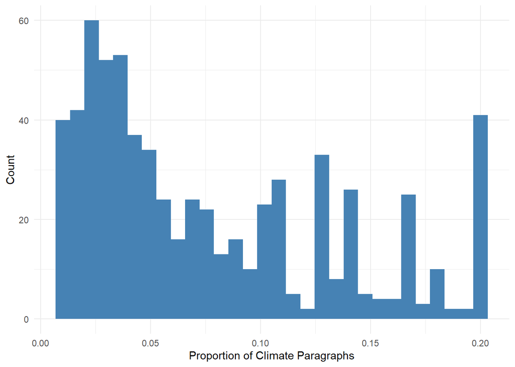

```r
df_plot <- business_classification |>
  filter(proportion_climate_paragraphs >= 0.01 & proportion_climate_paragraphs <= 0.2)

p <- ggplot(df_plot, aes(x = proportion_climate_paragraphs)) +
  geom_histogram(fill = "steelblue") +
  theme_minimal() +
  labs(
    x = "Proportion of Climate Paragraphs",
    y = "Count"
  )
ggsave(here("Outputs/05_proportion_climate_paragraphs_histogram.png"), p)
write_rds(p, here("Outputs/05_proportion_climate_paragraphs_histogram.rds"))
p
```

# Temporary business classification

```r
final_threshold <- 0.1

business_classification <- paragraphs_classified_wide |>
  group_by(BusinessShortNumber, Title) |>
  summarise(
    n_paragraphs = n(),
    n_climate_paragraphs = sum(dict_prediction),
    proportion_climate_paragraphs = n_climate_paragraphs / n_paragraphs,
    climate_temp = case_when(proportion_climate_paragraphs >= final_threshold ~ TRUE,
    .default = FALSE),
    large_bsn_check = case_when(n_climate_paragraphs > 1 & n_paragraphs >= 30 ~ TRUE,
    .default = FALSE),
    .groups = "drop"
  )
```

# LLM Review

In a next step, an LLM will be used to check the business Titles of climate_temp businesses and assign the final `climate` label. This is necessary to exclude false positives, i.e. businesses that contain some climate keywords but are not actually about climate topics.

```r
if (file.exists(here("Data/05_business_classification_final.rds"))) {

  business_classification_final <-
    read_rds(here("Data/05_business_classification_final.rds"))

} else {

  bn_clim <- business_classification |> filter(climate_temp == TRUE)

  prompt <- paste(readLines(here("label_review.txt")), collapse = " ")

  process_text <- function(text, index) {
    chat <- chat_openai(
      model = "gpt-5-mini",
      system_prompt = prompt
    )

    result <- tryCatch(
      {
        chat$chat(text)
      },
      error = function(e) {
        NA_character_
      }
    )

    return(result)
  }

  plan(multisession, workers = 4)

  reviews <- future_map2_chr(
    bn_clim$Title,
    seq_len(nrow(bn_clim)),
    process_text,
    .progress = TRUE,
    .options = furrr_options(seed = TRUE)
  )

  plan(sequential)

  bn_clim_reviewed <- bn_clim |>
    mutate(llm_review = reviews)

  business_classification_final <- business_classification |>
    left_join(
      bn_clim_reviewed |> select(BusinessShortNumber, llm_review),
      by = join_by(BusinessShortNumber)
    ) |>
    mutate(
      final_climate = case_when(
        climate_temp == TRUE & llm_review == "True Positive" ~ TRUE,
        climate_temp == TRUE & llm_review == "False Positive" ~ FALSE,
        .default = FALSE
      )
    )

  write_rds(business_classification_final, here("Data/05_business_classification_final.rds"))
}
```

# Climate Business Analysis

Plot some summary statistics about the climate businesses - Number of businesses with proportion_climate_paragraphs > 0 - Number of businesses in climate_temp - Number of businesses in final_climate

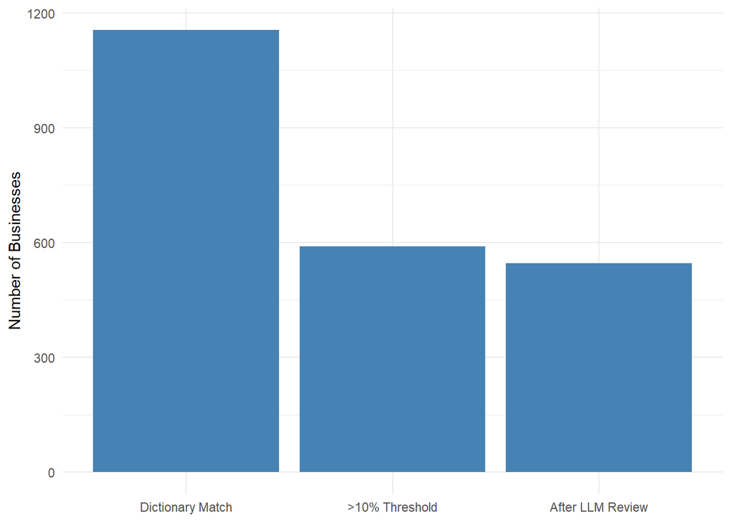

```r
categories = c("Dictionary Match", ">10% Threshold", "After LLM Review")

summary_stats <- tibble(
  category = factor(categories, levels = categories),
  count = c(
    nrow(business_classification_final |> filter(proportion_climate_paragraphs > 0)),
    sum(business_classification_final$climate_temp),
    sum(business_classification_final$final_climate)
  )
)

p <- ggplot(summary_stats, aes(x = category, y = count)) +
  geom_col(fill = "steelblue") +
  # geom_text(aes(label = count), vjust = 1.5, color = "white") +
  theme_minimal() +
  labs(x = NULL, y = "Number of Businesses") +
  theme(legend.position = "none")
ggsave(here("Outputs/05_business_classification_summary.png"), p)
write_rds(p, here("Outputs/05_business_classification_summary.rds"))
p
```

Plot the distribution of the number of paragraphs for final_climate.

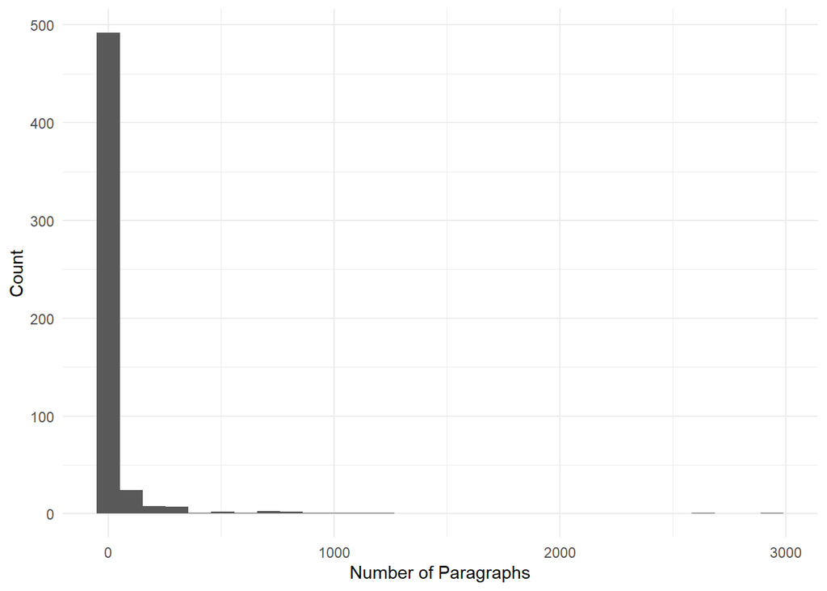

```r
df <- business_classification_final |>
  filter(final_climate == TRUE)

ggplot(df, aes(x = n_paragraphs)) +
geom_histogram() +
theme_minimal() +
labs(
  # title = "Distribution of Number of Paragraphs for Final Climate Businesses",
  x = "Number of Paragraphs",
  y = "Count"
)
```

There are a few very large businesses that make up a large proportion of the climate discourse.

Print the largest climate relevant businesses.

```r
business_classification_final |>
  filter(final_climate == TRUE) |>
  distinct(Title, n_paragraphs, proportion_climate_paragraphs) |>
  arrange(desc(n_paragraphs)) |>
  slice_head(n = 10) |>
  datatable()
```

|  | Title | n_paragraphs | proportion_climate_paragraphs |
| --- | --- | --- | --- |
| 1 | Totalrevision des CO2-Gesetzes nach 2020 | 2940 | 0.432312925170068 |
| 2 | Sichere Stromversorgung mit erneuerbaren Energien. Bundesgesetz | 2662 | 0.224267468069121 |
| 3 | Energiegesetz. Änderung (Beschleunigungserlass) | 1170 | 0.2094017094017094 |
| 4 | CO2-Gesetz für die Zeit nach 2024. Revision | 1139 | 0.4126426690079016 |
| 5 | Indirekter Gegenentwurf zur Gletscher-Initiative. Netto-Null-Treibhausgasemissionen bis 2050 | 1062 | 0.3248587570621469 |
| 6 | Für die Zukunft unserer Natur und Landschaft (Biodiversitätsinitiative). Volksinitiative und indirekter Gegenvorschlag | 916 | 0.2237991266375546 |
| 7 | Energiestrategie 2050, erstes Massnahmenpaket. Für den geordneten Ausstieg aus der Atomenergie (Atomausstiegsinitiative). Volksinitiative | 844 | 0.3578199052132701 |
| 8 | Stromversorgungsgesetz (Stromreserve). Änderung | 812 | 0.1416256157635468 |
| 9 | Nationalstrassen- und Agglomerationsverkehrs-Fonds (NAF). Schliessung der Finanzierungslücke und Strategisches Entwicklungsprogramm Nationalstrassen | 754 | 0.1061007957559682 |
| 10 | Um- und Ausbau der Stromnetze. Bundesgesetz | 745 | 0.1865771812080537 |

Print the largest non climate relevant businesses.

```r
business_classification_final |>
  filter(final_climate == FALSE) |>
  distinct(Title, n_paragraphs, proportion_climate_paragraphs) |>
  arrange(desc(n_paragraphs)) |>
  slice_head(n = 10) |>
  datatable()
```

|  | Title | n_paragraphs | proportion_climate_paragraphs |
| --- | --- | --- | --- |
| 1 | OR. Aktienrecht | 2640 | 0.001893939393939394 |
| 2 | Altersvorsorge 2020. Reform | 2074 | 0 |
| 3 | Strafrahmenharmonisierung und Anpassung des Nebenstrafrechts an das neue Sanktionenrecht | 1949 | 0 |
| 4 | Covid-19-Gesetz. Änderung und Zusatzkredit | 1772 | 0.001128668171557562 |
| 5 | Unternehmenssteuerreformgesetz III | 1740 | 0.001149425287356322 |
| 6 | Ausländergesetz. Steuerung der Zuwanderung und Vollzugsverbesserungen bei den Freizügigkeitsabkommen | 1593 | 0.001883239171374765 |
| 7 | Voranschlag 2025 mit integriertem Aufgaben- und Finanzplan 2026-2028 | 1531 | 0.02220770738079687 |
| 8 | Bundesgesetz über die Krankenversicherung. Änderung (Massnahmen zur Kostendämpfung - Paket 1) | 1448 | 0 |
| 9 | BVG-Reform | 1417 | 0.001411432604093155 |
| 10 | Stabilisierung der AHV (AHV 21) | 1386 | 0.002164502164502165 |

Print the climate businesses around the mean size of a climate business in the dataset.

```r
business_classification_final |>
  filter(final_climate == TRUE) |>
  distinct(Title, n_paragraphs, proportion_climate_paragraphs) |>
  slice_min(abs(n_paragraphs - mean(n_paragraphs)), n = 10) |>
  datatable()
```

|  | Title | n_paragraphs | proportion_climate_paragraphs |
| --- | --- | --- | --- |
| 1 | Einführung eines Online-Preisrechners für Treibstoffe | 52 | 0.1923076923076923 |
| 2 | Klimanotstand. Lenkungsabgabe für den Flugverkehr \| Besteuerung der Flugtickets in der Höhe der CO2-Abgabe auf Flugbenzin/Kerosin \| Einführung einer CO2-Abgabe auf Flugtickets \| Umweltabgabe auf Fl… | 53 | 0.5283018867924528 |
| 3 | Verschiebung der Einführung der Anforderung von 3,5 Prozent Biodiversitätsförderflächen im Ackerbau um ein Jahr | 53 | 0.1320754716981132 |
| 4 | Strommarkt 2.0. Strommarktliberalisierung, zweiter Schritt | 48 | 0.1875 |
| 5 | Energieautonomie der Immobilien des Bundes | 48 | 0.375 |
| 6 | Massnahmenplan zur Steigerung des Anteils des öffentlichen Verkehrs am Gesamtverkehr \| Massnahmenplan zur Steigerung des Anteils des öffentlichen Verkehrs am Gesamtverkehr \| Massnahmenplan zur Steig… | 48 | 0.1458333333333333 |
| 7 | Finanzielle Anreize für den Ersatz von alten Holzheizungen durch moderne Holzfeuerungsanlagen | 48 | 0.2916666666666667 |
| 8 | Stärkung der einheimischen Lebensmittelproduktion durch Aufschub des Vorhabens, mindestens 3,5 Prozent der offenen Ackerflächen neuen Biodiversitätsförderflächen zu widmen \| Abhängigkeiten vom Auslan… | 47 | 0.1276595744680851 |
| 9 | Laden von Elektroautos im Mietverhältnis und Stockwerkeigentum | 47 | 0.2978723404255319 |
| 10 | Errichtung von Anlagen zur Nutzung erneuerbarer Energien. Einschränkung des Beschwerderechts der Umweltorganisationen | 55 | 0.4545454545454545 |

Print the climate businesses just above the threshold.

```r
business_classification_final |>
  filter(final_climate == TRUE) |>
  distinct(Title, n_paragraphs, proportion_climate_paragraphs) |>
  arrange(proportion_climate_paragraphs) |>
  slice_head(n = 10) |>
  datatable()
```

|  | Title | n_paragraphs | proportion_climate_paragraphs |
| --- | --- | --- | --- |
| 1 | Weniger Parzellierung von landwirtschaftlichen Grundstücken. Mehr Kompetenzen für die Kantone | 10 | 0.1 |
| 2 | Verzicht auf die Revision der Gebührenverordnung des Bundesamtes für Zivilluftfahrt | 10 | 0.1 |
| 3 | Dosisgrenzwerte bei Kernkraftwerken | 10 | 0.1 |
| 4 | Mehr Sicherheit für den gleichen Preis | 10 | 0.1 |
| 5 | Wirksames Handeln gegen das Insektensterben | 10 | 0.1 |
| 6 | Stopp der missbräuchlichen MWST-Belastung auf Steuern und Abgaben bei Treibstoffen | 10 | 0.1 |
| 7 | Luftfahrtgesetz. Änderung | 10 | 0.1 |
| 8 | Verkehrsunfälle reduzieren. PS-Beschränkung für Auto-Junglenker und Auto-Junglenkerinnen | 10 | 0.1 |
| 9 | Alle Weine ins Zollkontingent aufnehmen | 10 | 0.1 |
| 10 | Leerkündigungen von Mieterinnen und Mietern bei Bauvorhaben (Arbeiten erleichtern und Wohnungen erhalten) | 10 | 0.1 |

Still a few False Positives, but OK since Topic Modeling handels Outliers well. Also, very small businesses that won’t have much influence on the overall topic modeling results.

Print non-climate businesses just below the threshold.

```r
business_classification_final |>
  filter(final_climate == FALSE, proportion_climate_paragraphs < final_threshold) |>
  distinct(Title, n_paragraphs, proportion_climate_paragraphs) |>
  arrange(desc(proportion_climate_paragraphs)) |>
  slice_head(n = 10) |>
  datatable()
```

|  | Title | n_paragraphs | proportion_climate_paragraphs |
| --- | --- | --- | --- |
| 1 | Finanzierung einer sicheren Stromversorgung von Polycom-Sendeanlagen des Bundes. Verpflichtungskredit | 51 | 0.09803921568627451 |
| 2 | Autobahn A1 auf sechs Spuren ausbauen | 51 | 0.09803921568627451 |
| 3 | Armeebotschaft 2021 | 197 | 0.09644670050761421 |
| 4 | Ausnahme des Modellflugs von der EU-Drohnenregelung | 52 | 0.09615384615384616 |
| 5 | Immobilienbotschaft zivil 2024 | 21 | 0.09523809523809523 |
| 6 | Die neue Massnahme von 3,5 Prozent Biodiversitätsförderflächen auf offener Ackerfläche wieder aufheben \| Sinnvolle Umsetzung der zusätzlichen 3,5 Prozent Biodiversitätsförderung auf Ackerflächen \| A… | 53 | 0.09433962264150944 |
| 7 | Forschungsförderinstrument SWEETER (Swiss research for the EnErgy Transition and Emissions Reduction) für die Jahre 2025-2036. Verpflichtungskredit | 150 | 0.09333333333333334 |
| 8 | Transformatorenstationen und andere elektrische Anlagen einfacher ermöglichen | 43 | 0.09302325581395349 |
| 9 | Agrarpolitik ab 2022 (AP22+) \| Zukünftige Ausrichtung der Agrarpolitik. Bericht des Bundesrates in Erfüllung der Postulate 20.3931 und 21.3015 | 249 | 0.09236947791164658 |
| 10 | Legislaturplanung 2019-2023 | 758 | 0.09234828496042216 |

Some medium-size businesses below the threshold with some climate relevance, but not enough to be classified as climate relevant. This weakness is acknowleged, but the threshold is necessary to ensure that the final climate classification is meaningful and not diluted by businesses with only marginal climate content.

# Paragraph-Level Climate Classification

Finally, the final climate label is assigned to the paragraphs table.

```r
paragraphs_classified_wide_final <- paragraphs_classified_wide |>
  left_join(
    business_classification_final |> select(BusinessShortNumber, final_climate),
    by = join_by(BusinessShortNumber)
  )

write_rds(
  paragraphs_classified_wide_final,
  here("Data/05_paragraphs_classified_wide_final.rds"))
```

Plot the distribution of the proportion of climate paragraphs for final_climate.

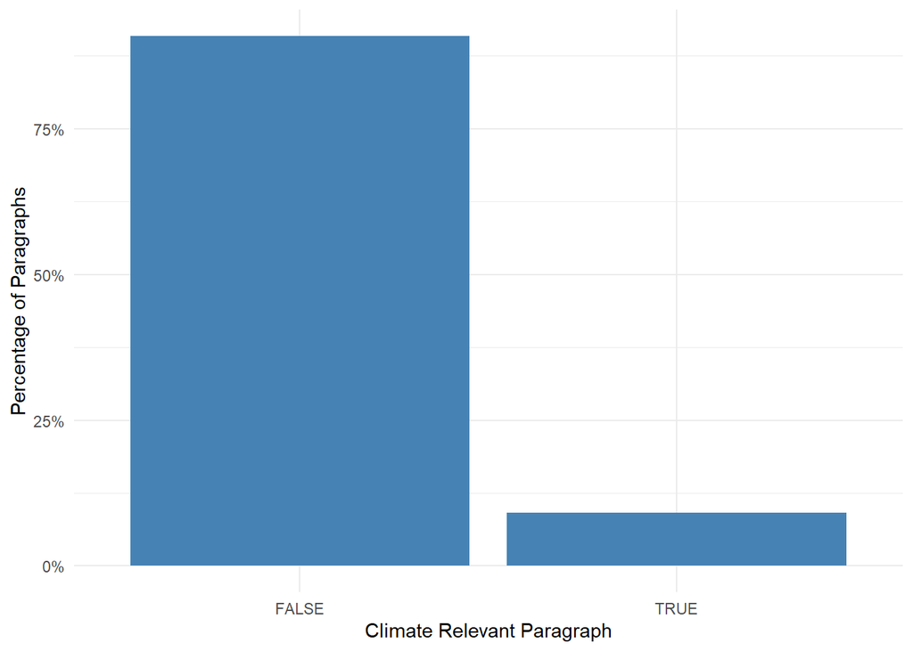

```r
p <- plot_categorical_distribution(
  paragraphs_classified_wide_final,
  group_col = "final_climate",
  x_label = "Climate Relevant Paragraph",
  # title = "Distribution of Climate Relevant Paragraphs",
  output_path = "Outputs/05_paragraphs_climate_distribution.png"
)
write_rds(p, here("Outputs/05_paragraphs_climate_distribution.rds"))
p
```

# Prepare Data for Topic Modeling

Prepare climate-related paragraphs and transcripts for topic modeling. Filter out very short texts to ensure meaningful topic extraction.

```r
transcripts_climate_summary <-
  paragraphs_classified_wide_final |>
  filter(final_climate == TRUE) |>
  group_by(transcript_id) |>
  summarise(
    transcript_text = paste(paragraph_text, collapse = " "),
    transcript_word_length = str_count(transcript_text, "\\S+"),
    .groups = "drop"
  ) |>
  filter(transcript_word_length >= 50)

write_csv(
  transcripts_climate_summary,
  here("Data/05_transcripts_climate_for_topic_modeling.csv")
)
```